# Final Project

Data Science II (STAT 301-2) - Holland Blumer

3/12/2020

# Table of Contents

1. Introduction: Data and Scope Identification
2. Works Cited
3. Load and Tidy Data: Data Cleaning and Processing
4. Relevant Information
5. Conclusion V. Appendices A. Appendix A: R code for loading data B. Appendix B: R code for tidying data C. Appendix C: R code for EDA D. Appendix D: R code for simple linear regression E. Appendix E: R code for cross validation F. Appendix F: R code for ridge/lasso G. Appendix G: R code for polynomial regression

# Overview

The datasets used for this project come from Google Trends and Yahoo Finance. When writing the memo for this project, there were (and still are) a lot of events in the news that would inherently impact my future health and career. At the time when I was writing the memo, the coronavirus was becoming more relevant in the news which resulted in multiple airplanes going into quarantine for 14 days. Additionally, there was a lot of political turmoil. Candidates were dropping out of the primary elections one by one and the senate was still deciding whether or not to impeach President Trump. As these events were happening, the stock price of Americal Airlines (AAL) dropped nearly 40 percent (Whiteman, 2020). I became curious about whether some of these events were tied to AAL’s stock. More specifically, I wanted to use this final project as an opportunity to test if the relevance of Joe Biden, Bernie Sanders, President Trump, Coronavirus, and American National Insurance Company (ANAT) predicted the stock price of AAL. Ultimately, I chose to extract data on the number of times people Googled “Joe Biden”, “Bernie Sanders”, “Coronavirus”, “Donald Trump”, in the last 90 days. I also downloaded historical data on the stock price of ANAT and AAL in the last 90 days. The predictors and response variables are all numeric.

Predictor Variables: coronavirus_count, biden_count, sanders_count, trump_count, close_anat Response Variable: close_aal (the closing price of AAL over the past 90 days)

# Classification

# Hypothesis

I hypothesize that all 5 predictor variables are valid to use when predicting the future price of the AAL stock.

## Datasets

I downloaded the datasets from either Google Trends or Yahoo Finance. On Google Trends, I downloaded data on how many people in the United States searched Bernie Sanders, Joe Biden, Donald Trump, and Coronavirus in the past 90 days. On Yahoo Finance, I downloaded historical data on the stock prices of ANAT and AAL in the past 90 days. I am mainly focused on the close prices of ANAT and AAL each day.

## Code book

coronavirus_90_days_dat: (factor) how many people in the US searched coronavirus on Google in the past 90 days (in the thousands) sanders_90_days_dat: (factor) how many people in the US searched Bernie Sanders on Google in the past 90 days (in the thousands) biden_90_days_dat: (factor) how many people in the US searched Joe Biden on Google in the past 90 days (in the thousands) trump_90_days_dat: (factor) how many people in the US searched Donal Trump on Google in the past 90 days (in the thousands) anat_90_days_dat: (factor) historical data on the American National Insurance Company (ANAT) stock price in the last 90 days aal_90_days_dat: (factor) historical data on American Airlines (AAL) stock in the last 90 days coronavirus_90_days_dat_tidy: (factor) removed header from coronavirus_90_days_dat sanders_90_days_dat_tidy: (factor) removed header from sanders_90_days_dat biden_90_days_dat_tidy: (factor) removed header from sanders_90_days_dat trump_90_days_dat_tidy: (factor) removed header from trump_90_days_dat anat_90_days_dat_tidy: (factor) data on close prices of ANAT stock and corresponding dates only aal_90_days_dat_tidy: (factor) data on close prices of AAL stock and corresponding dates only anat_aal_join: (factor) “placeholder” dataset that joins AAL’s close prices to ANAT’s close prices by date anat_aal_coronavirus_join: (factor) “placeholder” dataset that joins coronavirus_count to anat_aal_join by date anat_aal_coronavirus_sanders_join: (factor) “placeholder” dataset that joins sanders_count to anat_aal_coronavirus_join by date anat_aal_coronavirus_sanders_biden_join: (factor) “placeholder” dataset that joins biden_count to anat_aal_coronavirus_sanders_joi by date all_data_combined: (factor) dataset that joins all data, more specifically it joins trump_count to anat_aal_coronavirus_sanders_biden_join by date all_data_combined_tidy: (numeric) dataset that removes “<“ sign and converts factor variables to numeric all_data_combined_no_date: (numeric) dataset that’s similar to all_data_combined_tidy but removes date all_data_combined_no_date_numeric_remove_one: (numeric) dataset that removes all rows where coronavirus_count = 1 coronavirus_aal_plot: plots coronavirus_count vs close_aal biden_aal_plot: plots biden_count vs close_aal sanders_aal_plot: plots sanders_count vs close_aal trump_aal_plot: plots trump_count vs close_aal anat_aal_plot: plots close_anat vs close_aal

## Works Cited

Farley, Alan. “Airline Stocks Heading South After Coronavirus Scare.” Investopedia, Investopedia, 29 Jan. 2020, www.investopedia.com/airline-stocks-heading-south-after-coronavirus-scare-4782947.

“How to Convert Entire Dataframe to Numeric While Preserving Decimals?” Stack Overflow, 5 Aug. 2018, https://stackoverflow.com/questions/26391921/how-to-convert-entire-dataframe-to-numeric-while-preserving-decimals.

Kuyper, Arend. “Data Science Manual.” 3 Lab: Linear Regression, 1 Jan. 2020, https://nustat.github.io/data-science-manual/lab-linear-regression.html.

Kuyper, Arend. “Data Science Manual.” 3 Lab: Linear Regression, 1 Jan. 2020, https://nustat.github.io/data-science-manual/lab-linear-regression.html.

Kuyper, Arend. “Data Science Manual.” 6 Lab: Linear Model Selection and Regularization, 1 Jan. 2020, https://nustat.github.io/data-science-manual/lab-linear-model-selection-and-regularization.html.

Soergel, Andrew. “‘Biden Bump’ Signals Trouble for Trump.” U.S. News & World Report, U.S. News & World Report, 2020, www.usnews.com/news/elections/articles/2020-03-06/bidens-stock-surge-shows-trump-doesnt-own-the-economy.

Stokols, Eli. “Trump, Who Tied Himself to Stock Market When It Rose, Struggles to Respond to Its Plunge.” Los Angeles Times, Los Angeles Times, 9 Mar. 2020, www.latimes.com/politics/story/2020-03-09/trump-panic-tweets-as-markets-tank.

Whiteman, Lou. “Why Shares of Airline Stocks Are Falling Today.” Nasdaq, 2020, www.nasdaq.com/articles/why-shares-of-airline-stocks-are-falling-today-2020-03-05.

#### Load Packages

```r
knitr::opts_chunk$set(echo = FALSE)
library(MASS)
library(tidyverse)
library(janitor)
library(skimr)
library(modelr)
library(tidyr)
library(dplyr)
library(base)
library(ggplot2)
library(readr)
library(GGally)
library(grid)
library(gridExtra)
library(corrplot)
library(corrr)
library(class)
library(broom)
library(naniar)
library(rsample)
library(leaps) # find the best subset selection
library(glmnet) # ridge & lasso
library(glmnetUtils) # improves working with glmnet


conflicted::conflict_prefer("filter", "dplyr")
conflicted::conflict_prefer("select", "dplyr")
conflicted::conflict_prefer("setdiff", "dplyr")
conflicted::conflict_prefer("corrplot", "corrplot")

set.seed(26535) # Set the seed to make it reproducible
```

Data summary

| Name | coronavirus_90_days_dat |
| --- | --- |
| Number of rows | 91 |
| Number of columns | 2 |
| _______________________ |  |
| Column type frequency: |  |
| factor | 2 |
| ________________________ |  |
| Group variables | None |

**Variable type: factor**

Data summary

| skim_variable | n_missing | complete_rate | ordered | n_unique | top_counts |
| --- | --- | --- | --- | --- | --- |
| date | 0 | 1 | FALSE | 91 | 1/1: 1, 1/1: 1, 1/1: 1, 1/1: 1 |
| coronavirus_count | 0 | 1 | FALSE | 26 | <1: 37, 4: 8, 3: 5, 5: 5 |

| Name | sanders_90_days_dat |
| --- | --- |
| Number of rows | 91 |
| Number of columns | 2 |
| _______________________ |  |
| Column type frequency: |  |
| factor | 2 |
| ________________________ |  |
| Group variables | None |

**Variable type: factor**

Data summary

| skim_variable | n_missing | complete_rate | ordered | n_unique | top_counts |
| --- | --- | --- | --- | --- | --- |
| date | 0 | 1 | FALSE | 91 | 1/1: 1, 1/1: 1, 1/1: 1, 1/1: 1 |
| sanders_count | 0 | 1 | FALSE | 43 | 5: 10, 10: 7, 4: 7, 22: 5 |

| Name | biden_90_days_dat |
| --- | --- |
| Number of rows | 91 |
| Number of columns | 2 |
| _______________________ |  |
| Column type frequency: |  |
| factor | 2 |
| ________________________ |  |
| Group variables | None |

**Variable type: factor**

Data summary

| skim_variable | n_missing | complete_rate | ordered | n_unique | top_counts |
| --- | --- | --- | --- | --- | --- |
| date | 0 | 1 | FALSE | 91 | 1/1: 1, 1/1: 1, 1/1: 1, 1/1: 1 |
| biden_count | 0 | 1 | FALSE | 21 | 3: 19, 4: 16, 2: 15, 5: 7 |

| Name | trump_90_days_dat |
| --- | --- |
| Number of rows | 91 |
| Number of columns | 2 |
| _______________________ |  |
| Column type frequency: |  |
| factor | 2 |
| ________________________ |  |
| Group variables | None |

**Variable type: factor**

Data summary

| skim_variable | n_missing | complete_rate | ordered | n_unique | top_counts |
| --- | --- | --- | --- | --- | --- |
| date | 0 | 1 | FALSE | 91 | 1/1: 1, 1/1: 1, 1/1: 1, 1/1: 1 |
| trump_count | 0 | 1 | FALSE | 15 | 7: 27, 6: 23, 8: 13, 5: 6 |

| Name | anat_90_days_dat |
| --- | --- |
| Number of rows | 60 |
| Number of columns | 7 |
| _______________________ |  |
| Column type frequency: |  |
| factor | 1 |
| numeric | 6 |
| ________________________ |  |
| Group variables | None |

**Variable type: factor**

| skim_variable | n_missing | complete_rate | ordered | n_unique | top_counts |
| --- | --- | --- | --- | --- | --- |
| date | 0 | 1 | FALSE | 60 | 1/1: 1, 1/1: 1, 1/1: 1, 1/1: 1 |

**Variable type: numeric**

Data summary

| skim_variable | n_missing | complete_rate | mean | sd | p0 | p25 | p50 | p75 | p100 | hist |
| --- | --- | --- | --- | --- | --- | --- | --- | --- | --- | --- |
| open | 0 | 1 | 110.31 | 8.29 | 80.59 | 108.18 | 111.49 | 116.28 | 119.78 | ▁▁▂▆▇ |
| high | 0 | 1 | 111.47 | 7.90 | 84.12 | 109.92 | 113.51 | 117.27 | 120.14 | ▁▁▂▅▇ |
| low | 0 | 1 | 108.98 | 9.07 | 75.71 | 106.94 | 110.94 | 115.89 | 118.41 | ▁▁▂▃▇ |
| close_anat | 0 | 1 | 109.91 | 8.80 | 76.54 | 108.10 | 111.65 | 116.27 | 119.20 | ▁▁▂▃▇ |
| adj_close | 0 | 1 | 109.09 | 8.57 | 76.54 | 107.22 | 110.75 | 115.33 | 118.23 | ▁▁▂▃▇ |
| volume | 0 | 1 | 39795.00 | 19252.54 | 8400.00 | 26675.00 | 34300.00 | 50750.00 | 97700.00 | ▅▇▃▁▁ |

| Name | aal_90_days_dat |
| --- | --- |
| Number of rows | 61 |
| Number of columns | 7 |
| _______________________ |  |
| Column type frequency: |  |
| factor | 1 |
| numeric | 6 |
| ________________________ |  |
| Group variables | None |

**Variable type: factor**

| skim_variable | n_missing | complete_rate | ordered | n_unique | top_counts |
| --- | --- | --- | --- | --- | --- |
| date | 0 | 1 | FALSE | 61 | 1/1: 1, 1/1: 1, 1/1: 1, 1/1: 1 |

**Variable type: numeric**

| skim_variable | n_missing | complete_rate | mean | sd | p0 | p25 | p50 | p75 | p100 | hist |
| --- | --- | --- | --- | --- | --- | --- | --- | --- | --- | --- |
| open | 0 | 1 | 25.88 | 4.56 | 14.05 | 26.30 | 27.79 | 28.50 | 3.0030e+01 | ▁▁▁▁▇ |
| high | 0 | 1 | 26.37 | 4.40 | 15.60 | 26.60 | 28.26 | 28.88 | 3.0780e+01 | ▂▁▁▂▇ |
| low | 0 | 1 | 25.25 | 4.84 | 13.12 | 25.37 | 27.30 | 28.14 | 2.9990e+01 | ▂▁▁▁▇ |
| close_aal | 0 | 1 | 25.75 | 4.70 | 13.45 | 26.11 | 27.72 | 28.51 | 3.0470e+01 | ▁▁▁▁▇ |
| adj_close | 0 | 1 | 25.70 | 4.68 | 13.45 | 26.01 | 27.62 | 28.44 | 3.0470e+01 | ▁▁▁▁▇ |
| volume | 0 | 1 | 16937098.36 | 15320058.57 | 2373600.00 | 6898900.00 | 9852600.00 | 21573800.00 | 5.8319e+07 | ▇▂▁▁▁ |

```
## # A tibble: 91 x 2
##    date     coronavirus_count
##    <fct>    <fct>
##  1 Day      coronavirus: (United States)
##  2 12/15/19 <1
##  3 12/16/19 <1
##  4 12/17/19 <1
##  5 12/18/19 <1
##  6 12/19/19 <1
##  7 12/20/19 <1
##  8 12/21/19 <1
##  9 12/22/19 <1
## 10 12/23/19 <1
## # … with 81 more rows
```

```
## # A tibble: 91 x 2
##    date     sanders_count
##    <fct>    <fct>
##  1 Day      bernie sanders: (United States)
##  2 12/15/19 4
##  3 12/16/19 4
##  4 12/17/19 4
##  5 12/18/19 3
##  6 12/19/19 5
##  7 12/20/19 11
##  8 12/21/19 5
##  9 12/22/19 7
## 10 12/23/19 5
## # … with 81 more rows
```

```
## # A tibble: 91 x 2
##    date     trump_count
##    <fct>    <fct>
##  1 Day      donald trump: (United States)
##  2 12/15/19 6
##  3 12/16/19 6
##  4 12/17/19 6
##  5 12/18/19 24
##  6 12/19/19 100
##  7 12/20/19 19
##  8 12/21/19 11
##  9 12/22/19 9
## 10 12/23/19 7
## # … with 81 more rows
```

```
## # A tibble: 91 x 2
##    date     biden_count
##    <fct>    <fct>
##  1 Day      joe biden: (United States)
##  2 12/15/19 3
##  3 12/16/19 2
##  4 12/17/19 3
##  5 12/18/19 4
##  6 12/19/19 6
##  7 12/20/19 9
##  8 12/21/19 4
##  9 12/22/19 3
## 10 12/23/19 3
## # … with 81 more rows
```

```
## # A tibble: 60 x 7
##    date      open  high   low close_anat adj_close volume
##    <fct>    <dbl> <dbl> <dbl>      <dbl>     <dbl>  <dbl>
##  1 12/16/19  120.  120.  118.       118.      117.  32100
##  2 12/17/19  118.  120.  118.       119.      118.  37100
##  3 12/18/19  119.  120.  118.       118.      117.  86000
##  4 12/19/19  118.  120.  118.       119.      118.  21500
##  5 12/20/19  120.  120.  118.       119.      118.  97700
##  6 12/23/19  119.  119.  118.       118.      117.  31800
##  7 12/24/19  118.  119.  118        118.      117.   8400
##  8 12/26/19  118.  118.  117.       118.      117.  17000
##  9 12/27/19  118.  118.  116.       116.      115.  87900
## 10 12/30/19  116.  117.  116.       117.      116.  34000
## # … with 50 more rows
```

```
## # A tibble: 61 x 7
##    date      open  high   low close_aal adj_close   volume
##    <fct>    <dbl> <dbl> <dbl>     <dbl>     <dbl>    <dbl>
##  1 12/16/19  27.6  28.4  27.6      27.9      27.8  6997300
##  2 12/17/19  28.0  28.5  27.9      28.3      28.2  5920300
##  3 12/18/19  28.4  28.6  27.9      28        27.9  4633800
##  4 12/19/19  28    28.6  27.9      28.5      28.4  6295100
##  5 12/20/19  28.7  29.0  28.5      29.0      28.9 12277100
##  6 12/23/19  29.2  29.7  29.2      29.3      29.2  9291100
##  7 12/24/19  29.3  29.4  29.1      29.2      29.1  2373600
##  8 12/26/19  29.3  29.7  29.3      29.7      29.6  4746500
##  9 12/27/19  29.8  29.8  28.4      28.4      28.3  8416500
## 10 12/30/19  28.5  28.5  28.1      28.3      28.2  4940300
## # … with 51 more rows
```

```
## "","x"
## "1","processed data/all_data_combined_tidy.csv"
```

```
## "","x"
## "1","processed data/all_data_combined_no_date_numeric_remove_one.csv"
```

To begin the tidying process, I first removed any NA values in the dataset. I also needed to specify the “close” variable in both of the ANAT and AAL datasets by joining them. I also needed to remove the first row from the Google Trends dataset. There are more dates in the Google Trends datasets than the stock market datasets because the stock market is only open on certain days of the week. Instead of deleting the rows with the extra dates, I used left join to join the datasets. I needed to join the stock market datasets first to avoid getting NA values. Additionally, I removed the “>” sign from the coronavirus_count. I then decided that changing the “>1” to 1 would impact the correlation between coronavirus_count and close_aal. Thus, I made the dataset smaller and removed all but one rows where coronavirus_count was 1. To do EDA later like corrplot, I needed to change all the values to numeric. (See Appendix B)

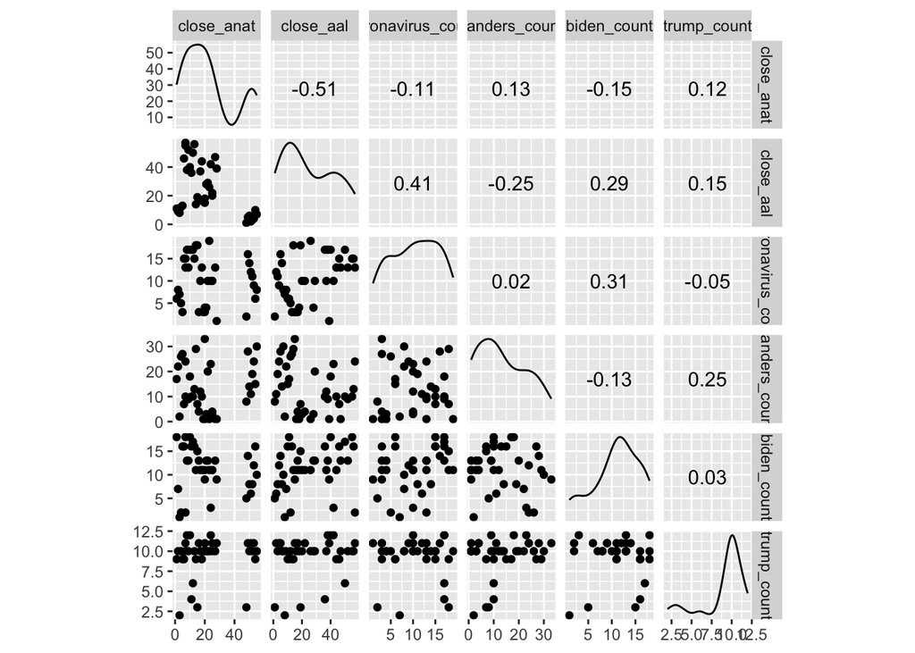

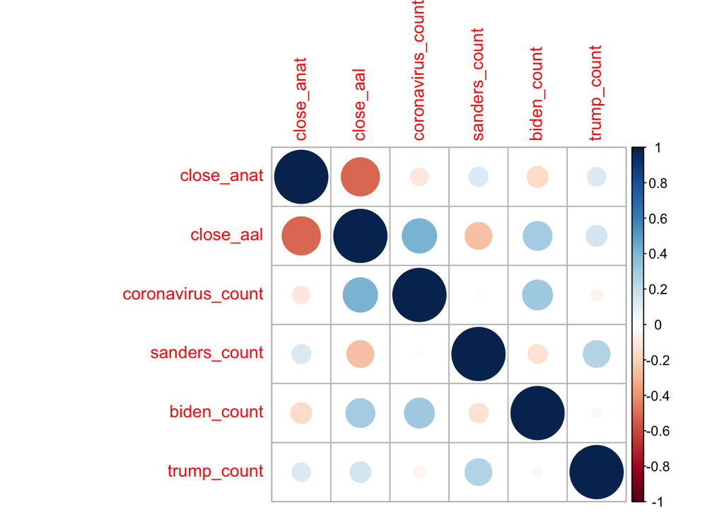

Table: Data summary

| Name | Piped data |
| --- | --- |
| Number of rows | 38 |
| Number of columns | 6 |
| _______________________ |  |
| Column type frequency: |  |
| numeric | 6 |
| ________________________ |  |
| Group variables | None |

**Variable type: numeric**

Data summary

| skim_variable | n_missing | complete_rate | mean | sd | p0 | p25 | p50 | p75 | p100 |
| --- | --- | --- | --- | --- | --- | --- | --- | --- | --- |
| close_anat | 0 | 1 | 22.21 | 16.95 | 1 | 9.25 | 18.5 | 26.50 | 55 |
| close_aal | 0 | 1 | 25.11 | 17.69 | 1 | 10.25 | 19.5 | 39.75 | 57 |
| coronavirus_count | 0 | 1 | 10.39 | 5.34 | 1 | 6.00 | 10.0 | 15.00 | 19 |
| sanders_count | 0 | 1 | 13.32 | 9.67 | 1 | 4.75 | 10.5 | 21.50 | 33 |
| biden_count | 0 | 1 | 11.26 | 4.61 | 1 | 9.00 | 11.0 | 14.75 | 18 |
| trump_count | 0 | 1 | 9.37 | 2.47 | 2 | 9.00 | 10.0 | 11.00 | 12 |

| Name | all_data_combined_no_date… |
| --- | --- |
| Number of rows | 38 |
| Number of columns | 6 |
| _______________________ |  |
| Column type frequency: |  |
| numeric | 6 |
| ________________________ |  |
| Group variables | None |

**Variable type: numeric**

| skim_variable | n_missing | complete_rate | mean | sd | p0 | p25 | p50 | p75 | p100 | hist |
| --- | --- | --- | --- | --- | --- | --- | --- | --- | --- | --- |
| close_anat | 0 | 1 | 22.21 | 16.95 | 1 | 9.25 | 18.5 | 26.50 | 55 | ▇▇▃▁▅ |
| close_aal | 0 | 1 | 25.11 | 17.69 | 1 | 10.25 | 19.5 | 39.75 | 57 | ▇▆▂▅▅ |
| coronavirus_count | 0 | 1 | 10.39 | 5.34 | 1 | 6.00 | 10.0 | 15.00 | 19 | ▇▅▆▇▇ |
| sanders_count | 0 | 1 | 13.32 | 9.67 | 1 | 4.75 | 10.5 | 21.50 | 33 | ▇▇▃▃▃ |
| biden_count | 0 | 1 | 11.26 | 4.61 | 1 | 9.00 | 11.0 | 14.75 | 18 | ▂▂▇▅▆ |
| trump_count | 0 | 1 | 9.37 | 2.47 | 2 | 9.00 | 10.0 | 11.00 | 12 | ▂▁▁▇▃ |

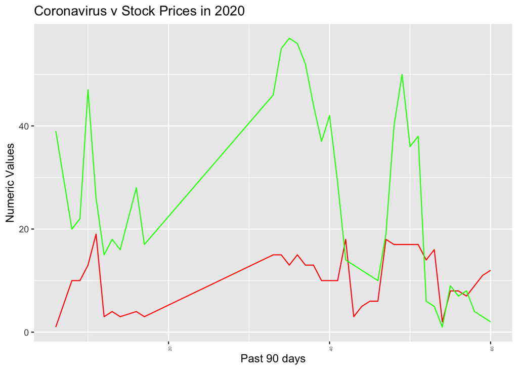

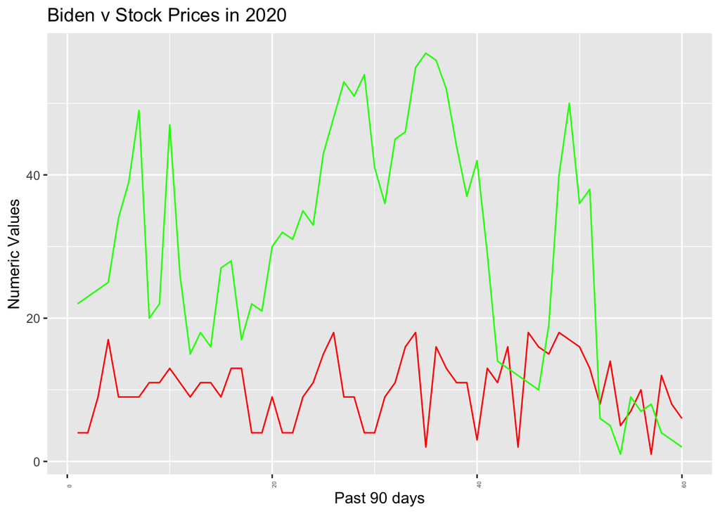

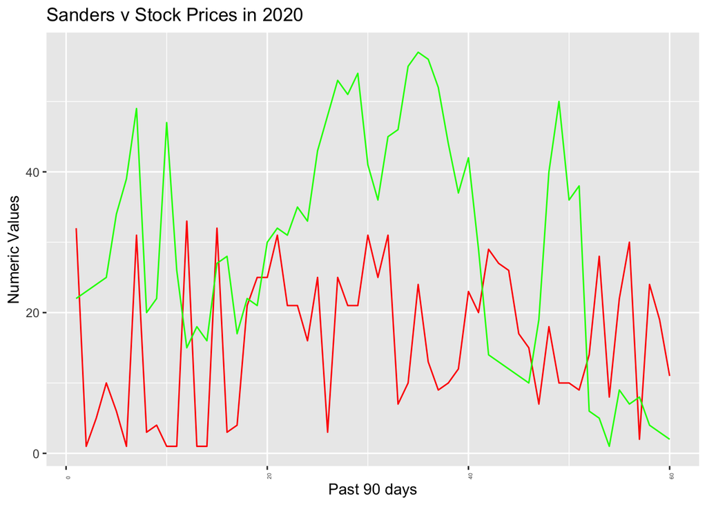

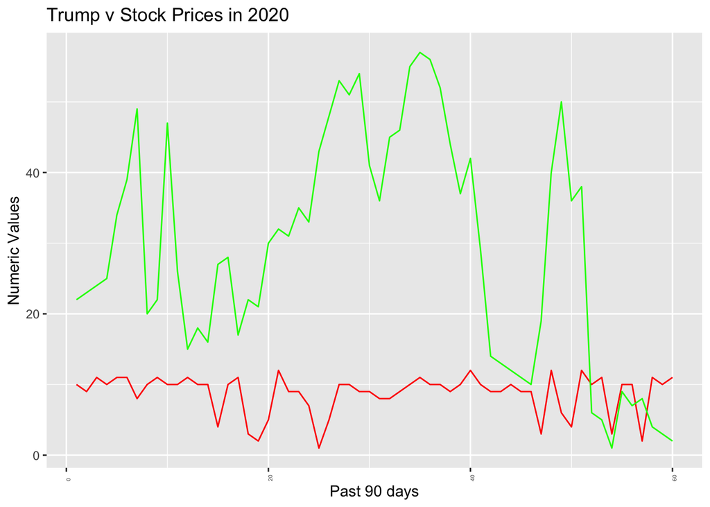

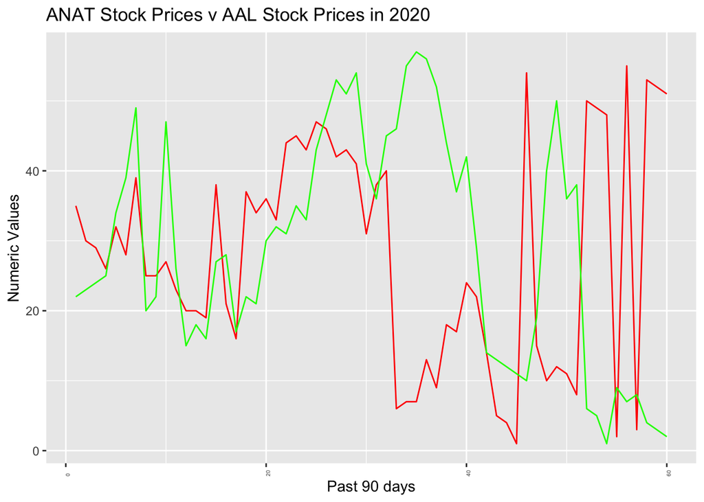

```
##
## Call:
## lm(formula = close_aal ~ coronavirus_count, data = .)
##
## Residuals:
##      Min       1Q   Median       3Q      Max
## -27.8055 -12.5401   0.5533  14.0354  28.3157
##
## Coefficients:
##                   Estimate Std. Error t value Pr(>|t|)
## (Intercept)        10.8254     5.8535   1.849  0.07263 .
## coronavirus_count   1.3738     0.5023   2.735  0.00962 **
## ---
## Signif. codes:  0 '***' 0.001 '**' 0.01 '*' 0.05 '.' 0.1 ' ' 1
##
## Residual standard error: 16.31 on 36 degrees of freedom
## Multiple R-squared:  0.172,  Adjusted R-squared:  0.149
## F-statistic: 7.481 on 1 and 36 DF,  p-value: 0.009618
```

```
## # A tibble: 1 x 11
##   r_squared adj_r_squared sigma statistic p_value    df log_lik   aic   bic
##       <dbl>         <dbl> <dbl>     <dbl>   <dbl> <int>   <dbl> <dbl> <dbl>
## 1     0.172         0.149  16.3      7.48 0.00962     2   -159.  324.  329.
## # … with 2 more variables: deviance <dbl>, df_residual <int>
```

```
## # A tibble: 2 x 7
##   term              estimate std_error statistic p_value conf_low conf_high
##   <chr>                <dbl>     <dbl>     <dbl>   <dbl>    <dbl>     <dbl>
## 1 (Intercept)          10.8      5.85       1.85 0.0726    -1.05      22.7
## 2 coronavirus_count     1.37     0.502      2.74 0.00962    0.355      2.39
```

```
## # A tibble: 3 x 3
##     fit   lwr   upr
##   <dbl> <dbl> <dbl>
## 1  27.3  21.7  32.9
## 2  36.9  26.6  47.2
## 3  53.4  31.7  75.1
```

```
## # A tibble: 3 x 3
##     fit   lwr   upr
##   <dbl> <dbl> <dbl>
## 1  27.3 -6.25  60.9
## 2  36.9  2.28  71.6
## 3  53.4 13.9   93.0
```

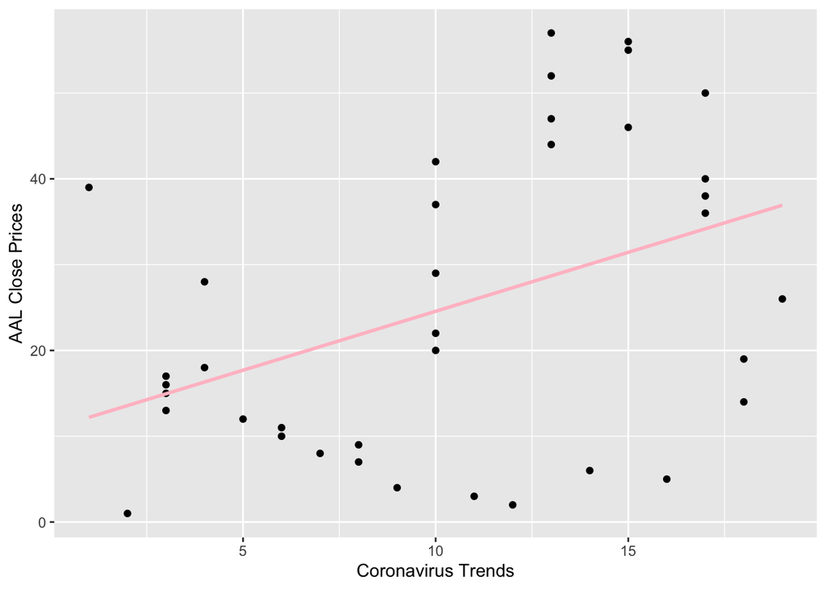

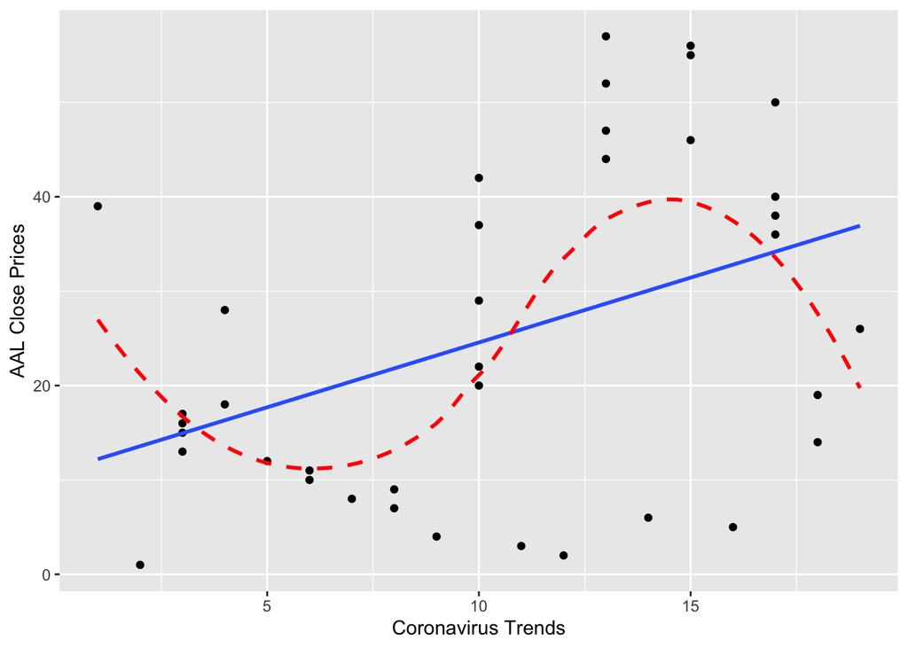

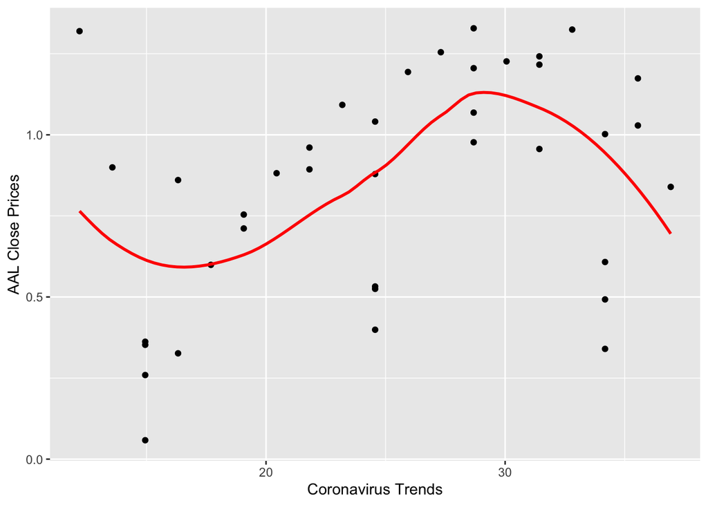

There seems to be a slight response in close_aal as coronavirus_count increases. A polynomial fit seems more suitable for this relationship. Next we are going to run multiple linear regression using all the variables: biden_count, sanders_count, trump_count, anat_close and coronavirus_count. I will keep in mind that there are many more factors that impact the AAL stock price.

```
## # A tibble: 1 x 1
##   data
##   <list>
## 1 <df[,6] [38 × 6]>
```

Now, I want to assess the models I just used with AIC.

```
## # A tibble: 7 x 14
##   model_name   AIC data  model_fit r.squared adj.r.squared sigma statistic
##   <chr>      <dbl> <lis> <list>        <dbl>         <dbl> <dbl>     <dbl>
## 1 mod_06      311. <df[… <lm>          0.519         0.444  13.2      6.91
## 2 mod_07      312. <df[… <lm>          0.710         0.512  12.3      3.59
## 3 mod_02      322. <df[… <lm>          0.356         0.255  15.3      3.53
## 4 mod_01      324. <df[… <lm>          0.172         0.149  16.3      7.48
## 5 mod_03      325. <df[… <lm>          0.201         0.156  16.3      4.41
## 6 mod_04      325. <df[… <lm>          0.228         0.160  16.2      3.34
## 7 mod_05      326. <df[… <lm>          0.214         0.144  16.4      3.08
## # … with 6 more variables: p.value <dbl>, df <int>, logLik <dbl>, BIC <dbl>,
## #   deviance <dbl>, df.residual <int>
```

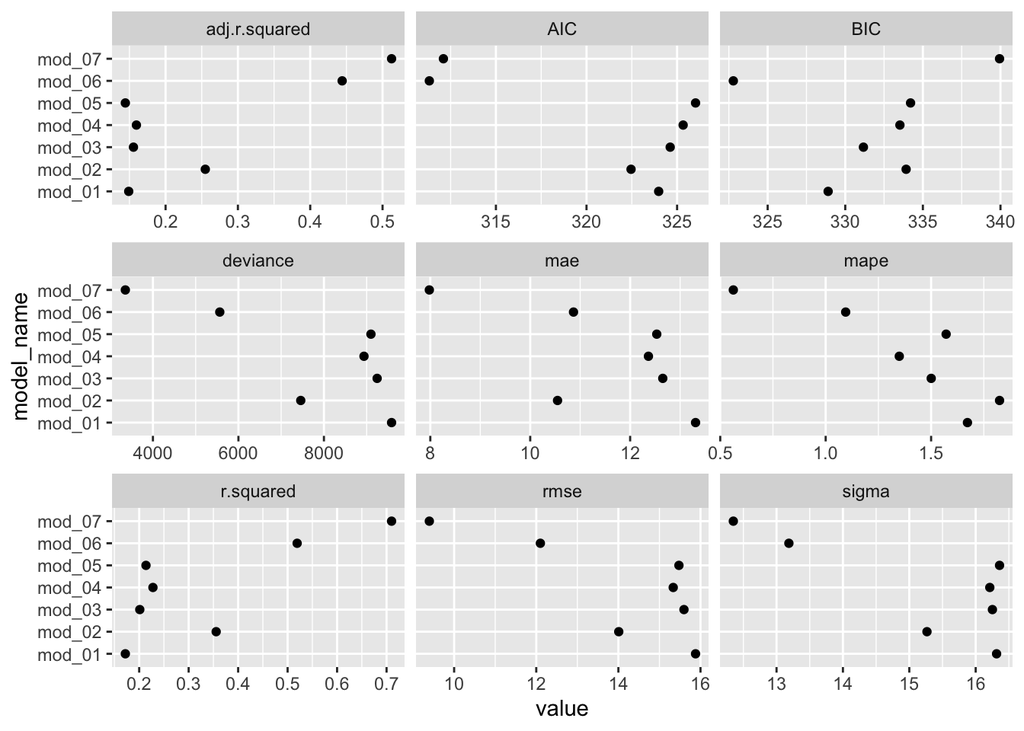

Model 6 and 7 do a better job at fitting the data because they are more flexible. Next, I will use graphics to compare the coefficients of the predictor variables. Similar to what we learned in Chapter 3.5 of the Datascience Manual, I want to plot the 95% confidence intervals for each model with a variety of variables.

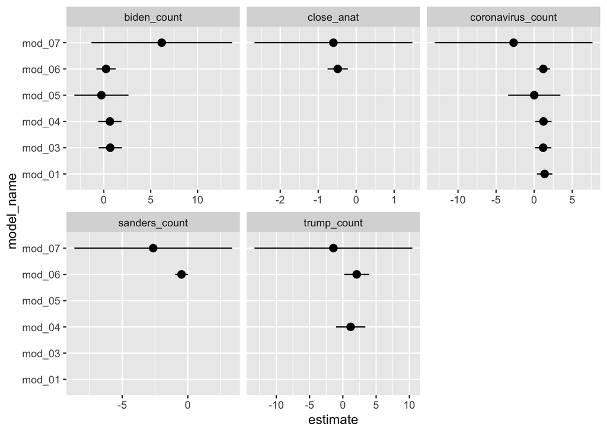

Similar to the Datascience manual, Mod 02 is not present because it is a polynomial fit and therefore not compatible given its orthogonalization fitting method. To compare the polynomial fit to a simple linear fit, we will use the following graph.

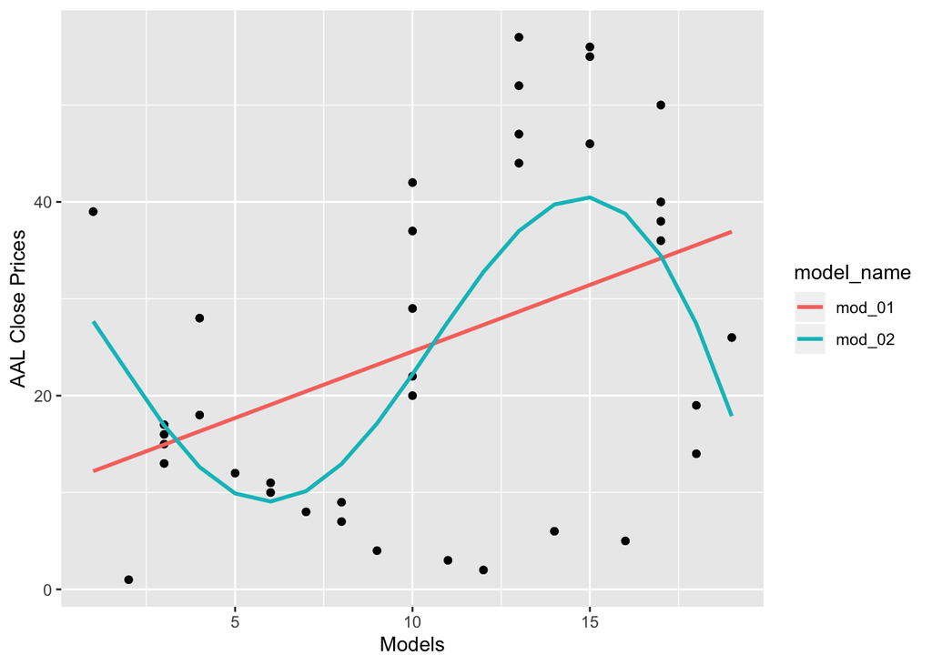

As expected, it seems like Mod 02 fits the underlying pattern of data points here. Next, I am going to build cross validation approaches to estimate the test error rates from fitting linear models to the all_data_combined dataset.

Since this is a really small dataset, I decided to split the data 80/20. This will hold 20% of the data out from the fitting process.

```
## # A tibble: 5 x 2
##   degree test_mse
##    <int>    <dbl>
## 1      3     224.
## 2      5     227.
## 3      4     229.
## 4      1     272.
## 5      2     282.
```

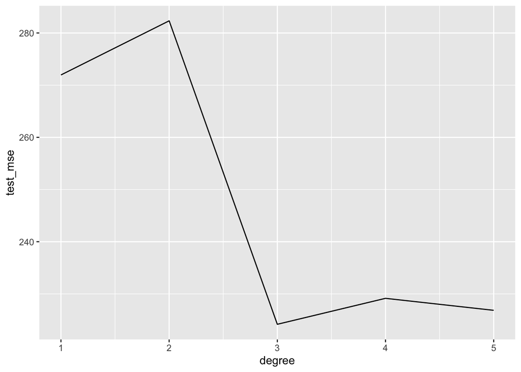

The polynomial model of the 3rd degree has the lowest test_mse.

```
## # A tibble: 5 x 2
##   degree test_mse
##    <int>    <dbl>
## 1      3     241.
## 2      4     277.
## 3      1     279.
## 4      2     301.
## 5      5     397.
```

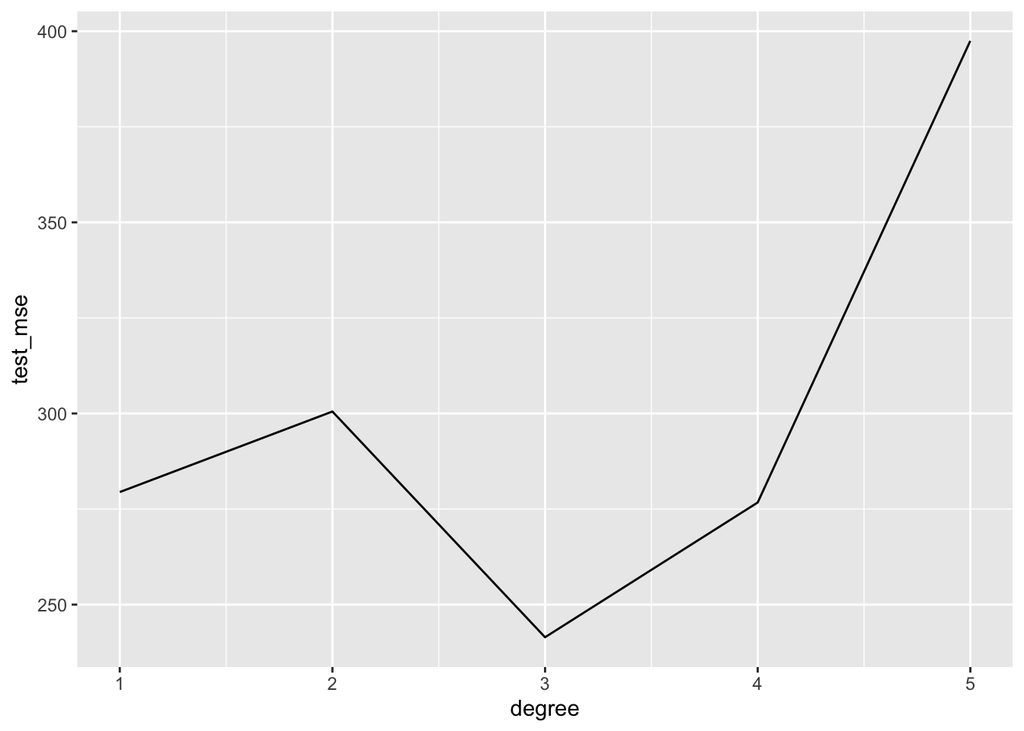

According to LOOCV, the degree 3 model has the lowest test_mse.

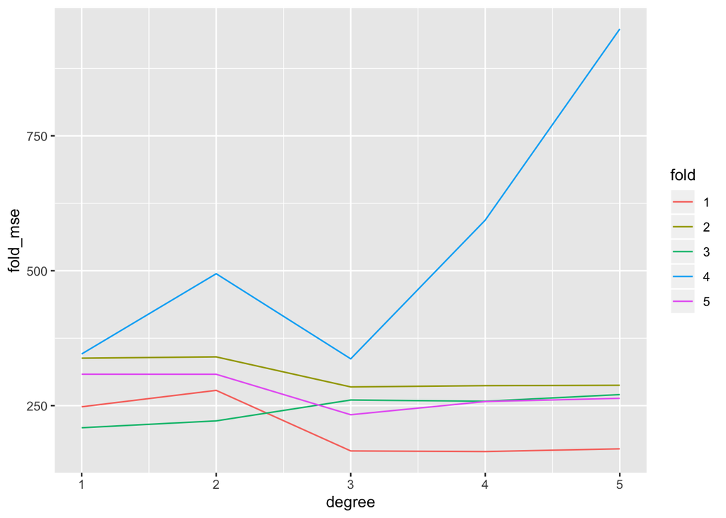

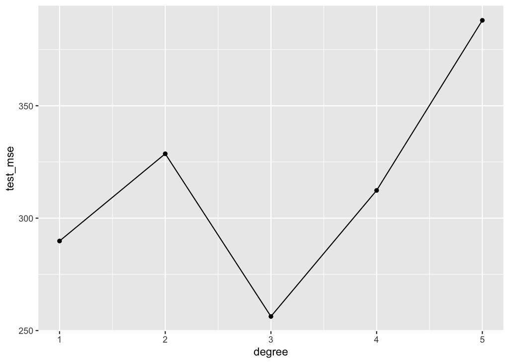

Given my dataset is small, I used 5 folds for the K-fold cross validation. For the subset selection method in the next analysis, it seems reasonable to set the sample fraction to .2.

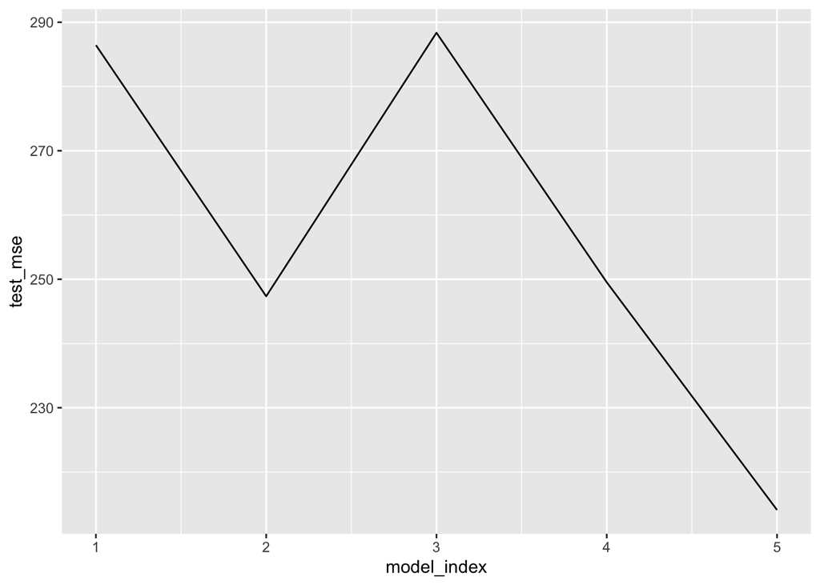

```
## # A tibble: 5 x 2
##   model_index test_mse
##         <int>    <dbl>
## 1           5     214.
## 2           2     247.
## 3           4     250.
## 4           1     286.
## 5           3     288.
```

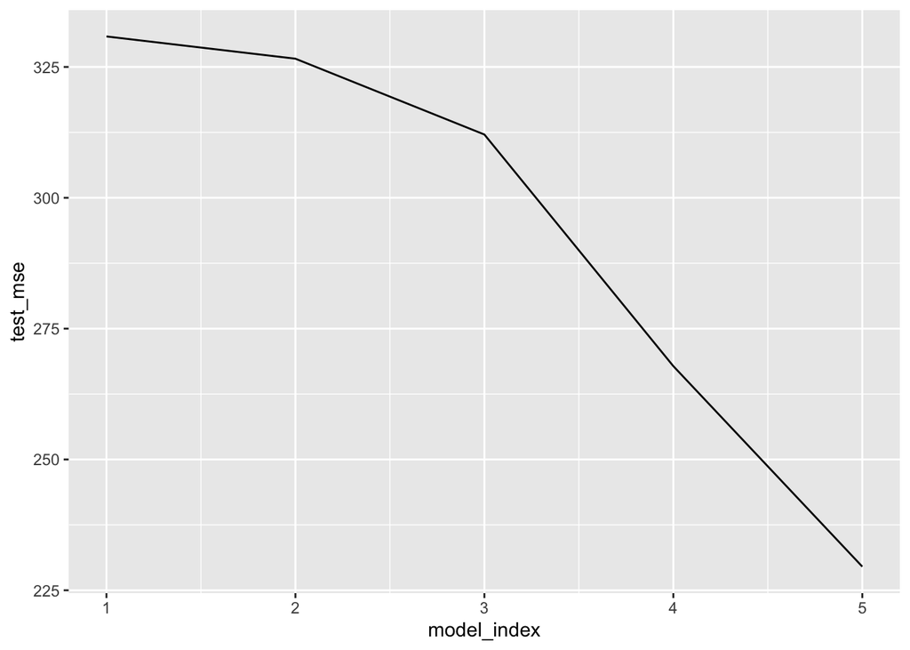

```
## # A tibble: 5 x 2
##   model_index test_mse
##         <int>    <dbl>
## 1           5     230.
## 2           4     268.
## 3           3     312.
## 4           2     327.
## 5           1     331.
```

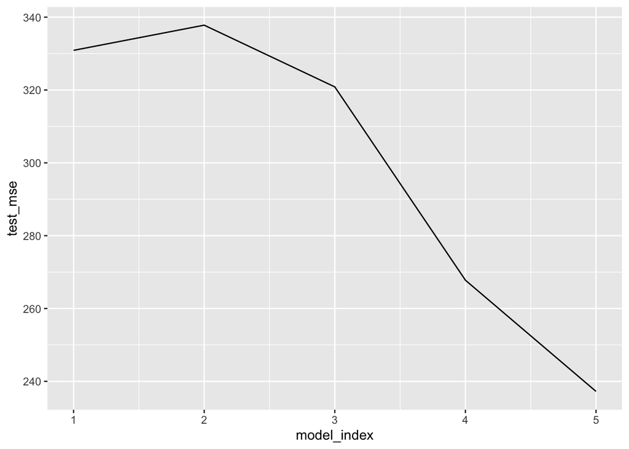

```
## # A tibble: 5 x 2
##   model_index test_mse
##         <int>    <dbl>
## 1           5     237.
## 2           4     268.
## 3           3     321.
## 4           1     331.
## 5           2     338.
```

The exhaustive method, forward selection, and backward selection method suggests using all 5 predictors since that gives us the lowest test MSE. The best subset validation method calculates lower test MSE values.

```
## # A tibble: 3 x 4
##   train             test             method         fit
##   <list>            <list>           <chr>          <list>
## 1 <df[,6] [30 × 6]> <df[,6] [8 × 6]> best_subset    <regsbsts>
## 2 <df[,6] [30 × 6]> <df[,6] [8 × 6]> fwd_selection  <regsbsts>
## 3 <df[,6] [30 × 6]> <df[,6] [8 × 6]> back_selection <regsbsts>
```

[output not shown]

According to the top of the lasso graph, the number of predictors decrease as lambdas increases. This observation validates that ridge and lasso are working. In the next phase, we will calculate and compare test errors. We should remember to remove date variable from the dataset.

[output not shown]

| method | test_mse |
| --- | --- |
| lasso_1se | 231.0418 |
| ridge_1se | 239.0628 |
| ridge_min | 240.3670 |
| lasso_min | 241.4236 |
| best_subset | 241.9827 |
| fwd_selection | 241.9827 |
| back_selection | 241.9827 |

I chose to split the data 80/20.

```
## # A tibble: 5 x 3
##   model_name test_mse pct_diff
##   <chr>         <dbl>    <dbl>
## 1 degree 2       249.      0
## 2 degree 1       326.     30.7
## 3 degree 5       915.    267.
## 4 degree 3       933.    274.
## 5 degree 4      2865.   1049.
```

Degree 2 and 1 seem pretty reasonable, so I’m going to test that.

```
## # A tibble: 2 x 2
##   model_name test_mse
##   <chr>         <dbl>
## 1 degree 2       239.
## 2 degree 1       326.
```

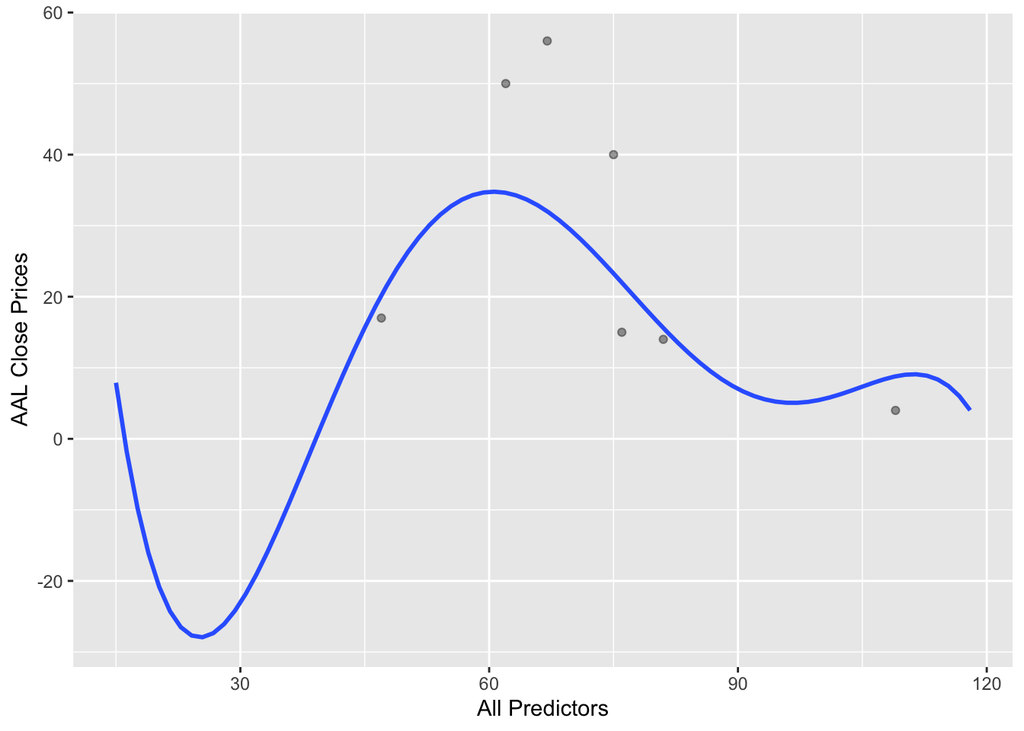

# Discussion/Conclusion

Lasso 1SE Regression selected the best models as it had the lowest test MSE. The lambda value was within 1 SD to predict the close price of AAL stock in the past couple of months. As hypothesized, the relevance of coronavirus does seem to impact American Airline’s stock. This makes sense because customers are afraid to sit in a confined area surrounded by potentially sick people. Biden_count was also a good predictor of close_AAL. This is interesting because there is an article from US News claiming that Biden would be better for the economy than Bernie Sanders (Soergel, 2020). There is another article discussing how Trump is tanking the stock market (Stokols, 2020). From the analysis, there’s not enough information to conclude that the relevance of Trump or Sanders predicts the closing price of AAL. In the future, I might use some of these predictors to invest more in American Airlines stock. If I do more analysis on the relevance of President Trump and Sanders, I might want to sell my stock in AAL. In the future, I want to add a line of code beside the that indicates if the stock market has gone up or down from the day before and perform logistic regression on the dataset. This addition might help when it comes to making quick trades on the market through R code. I also want to run PLS/PCR as there are potentially better models out there. Lastly, I want to get more data (perhaps from the past 180 days) and exclude coronavirus since no one was searching it last year.

# Appendix A: Load Packages and Data

library(MASS) library(tidyverse) library(janitor) library(skimr) library(modelr) library(tidyr) library(dplyr) library(base) library(ggplot2) library(readr) library(GGally) library(grid) library(gridExtra) library(corrplot) library(corrr) library(class) library(broom) library(naniar) library(rsample) library(leaps) # find the best subset selection library(glmnet) # ridge & lasso library(glmnetUtils) # improves working with glmnet

conflicted::conflict_prefer(“filter”, “dplyr”) conflicted::conflict_prefer(“select”, “dplyr”) conflicted::conflict_prefer(“setdiff”, “dplyr”) conflicted::conflict_prefer(“corrplot”, “corrplot”)

set.seed(26535) # Set the seed to make it reproducible

# Load Data

coronavirus_90_days_dat <- read_csv(“data/coronavirus_US_90_days.csv”) %>% clean_names() %>% rename(date = category_all_categories) %>% rename(coronavirus_count = x2) %>% mutate_if(is_character, factor) %>% clean_names()

sanders_90_days_dat <- read_csv(“data/bernie_sanders_90_days.csv”) %>% clean_names() %>% rename(date = category_all_categories) %>% rename(sanders_count = x2) %>% mutate_if(is_character, factor) %>% clean_names()

biden_90_days_dat <- read_csv(“data/joe_biden_90_days.csv”) %>% clean_names() %>% rename(date = category_all_categories) %>% rename(biden_count = x2) %>% mutate_if(is_character, factor) %>% clean_names()

trump_90_days_dat <- read_csv(“data/donald_trump_90_days.csv”) %>% clean_names() %>% rename(date = category_all_categories) %>% rename(trump_count = x2) %>% mutate_if(is_character, factor) %>% clean_names()

anat_90_days_dat <- read_csv(“data/ANAT_yahoo_90_days.csv”) %>% clean_names() %>% rename(close_anat = close) %>% mutate_if(is_character, factor)

aal_90_days_dat <- read_csv(“data/AAL_yahoo_90_days.csv”) %>% clean_names() %>% rename(close_aal = close) %>% mutate_if(is_character, factor)

# Appendix B: Tidy Data

# Skim

skim(coronavirus_90_days_dat)

skim(sanders_90_days_dat)

skim(biden_90_days_dat)

skim(trump_90_days_dat)

skim(anat_90_days_dat)

skim(aal_90_days_dat)

# omit any NA values

coronavirus_90_days_dat %>% na.omit()

sanders_90_days_dat %>% na.omit()

trump_90_days_dat %>% na.omit()

biden_90_days_dat %>% na.omit()

anat_90_days_dat %>% na.omit()

aal_90_days_dat %>% na.omit()

coronavirus_90_days_dat_tidy <- coronavirus_90_days_dat[c(2:91), ]

sanders_90_days_dat_tidy <- sanders_90_days_dat[c(2:91), ]

biden_90_days_dat_tidy <- biden_90_days_dat[c(2:91), ]

trump_90_days_dat_tidy <- trump_90_days_dat[c(2:91), ]

anat_90_days_dat_tidy <- anat_90_days_dat %>% select(-high, -low, -adj_close, -volume, -open)

aal_90_days_dat_tidy <- aal_90_days_dat %>% select(-high, -low, -adj_close, -volume, -open)

anat_aal_join <- left_join(anat_90_days_dat_tidy, aal_90_days_dat_tidy , by=c(“date”))

anat_aal_coronavirus_join <- left_join(anat_aal_join, coronavirus_90_days_dat_tidy , by=c(“date”))

anat_aal_coronavirus_sanders_join <- left_join(anat_aal_coronavirus_join, sanders_90_days_dat_tidy , by=c(“date”))

anat_aal_coronavirus_sanders_biden_join <- left_join(anat_aal_coronavirus_sanders_join, biden_90_days_dat_tidy , by=c(“date”))

all_data_combined <- left_join(anat_aal_coronavirus_sanders_biden_join, trump_90_days_dat_tidy , by=c(“date”))

# For the coronavirus dataset, we need to change the less than 1 value to 1 to run appropriate regression methods

all_data_combined_tidy <- as.data.frame(sapply(all_data_combined, gsub, pattern = “<|>”, replacement = ""))

all_data_combined_tidy <- data.frame(lapply(all_data_combined_tidy, function(x) as.numeric(as.factor(x))))

all_data_combined_no_date <- all_data_combined_tidy %>% select(-date)

all_data_combined_no_date_numeric <- data.frame(lapply(all_data_combined_no_date, function(x) as.numeric(as.factor(x))))

all_data_combined_no_date_numeric_remove_one <- all_data_combined_no_date_numeric[c(23:60), ]

all_data_combined_no_date_numeric_remove_one

# Appendix C: EDA

ggscatmat(all_data_combined_no_date_numeric_remove_one)

all_data_combined_no_date_numeric_remove_one %>% cor(use=“pairwise.complete.obs”) %>% corrplot()

all_data_combined_no_date_numeric_remove_one %>% skim_without_charts()

skim(all_data_combined_no_date_numeric_remove_one )

coronavirus_aal_plot <- all_data_combined_tidy %>% ggplot(aes(all_data_combined_tidy$date, group = 1)) + geom_line(aes(y=coronavirus_count, group = 1), color=“red”) +  
geom_line(aes(y=close_aal, group = 1), color=“green”) + xlab(“Past 90 days”) + ylab(“Numeric Values”) + ggtitle(“Coronavirus v Stock Prices in 2020”) + theme(axis.text.x = element_text(angle = 90, hjust = 0, size = 4), legend.title = element_blank()) coronavirus_aal_plot

biden_aal_plot <- all_data_combined_tidy %>% ggplot(aes(all_data_combined_tidy$date, group = 1)) + geom_line(aes(y=biden_count, group = 1), color=“red”) +  
geom_line(aes(y=close_aal, group = 1), color=“green”) + xlab(“Past 90 days”) + ylab(“Numeric Values”) + ggtitle(“Biden v Stock Prices in 2020”) + theme(axis.text.x = element_text(angle = 90, hjust = 0, size = 4), legend.title = element_blank()) biden_aal_plot

sanders_aal_plot <- all_data_combined_tidy %>% ggplot(aes(all_data_combined_tidy$date, group = 1)) + geom_line(aes(y=sanders_count, group = 1), color=“red”) +  
geom_line(aes(y=close_aal, group = 1), color=“green”) + xlab(“Past 90 days”) + ylab(“Numeric Values”) + ggtitle(“Sanders v Stock Prices in 2020”) + theme(axis.text.x = element_text(angle = 90, hjust = 0, size = 4), legend.title = element_blank()) sanders_aal_plot

trump_aal_plot <- all_data_combined_tidy %>% ggplot(aes(all_data_combined_tidy$date, group = 1)) + geom_line(aes(y=trump_count, group = 1), color=“red”) +  
geom_line(aes(y=close_aal, group = 1), color=“green”) + xlab(“Past 90 days”) + ylab(“Numeric Values”) + ggtitle(“Trump v Stock Prices in 2020”) + theme(axis.text.x = element_text(angle = 90, hjust = 0, size = 4), legend.title = element_blank()) trump_aal_plot

anat_aal_plot <- all_data_combined_tidy %>% ggplot(aes(all_data_combined_tidy$date, group = 1)) + geom_line(aes(y=close_anat, group = 1), color=“red”) +  
geom_line(aes(y=close_aal, group = 1), color=“green”) + xlab(“Past 90 days”) + ylab(“Numeric Values”) + ggtitle(“ANAT Stock Prices v AAL Stock Prices in 2020”) + theme(axis.text.x = element_text(angle = 90, hjust = 0, size = 4), legend.title = element_blank()) anat_aal_plot

# Appendix D: Simple Linear Regression

lm_fit <- all_data_combined_no_date_numeric_remove_one %>% lm(formula = close_aal ~ coronavirus_count)

lm_fit %>% summary()

lm_fit %>% glance() %>% clean_names()

lm_fit %>% tidy() %>% bind_cols(lm_fit %>% confint_tidy()) %>% clean_names()

# Confidence and Prediction Intervals

coronavirus_sample_data <- tibble(coronavirus_count = c(12, 19, 31))

coronavirus_sample_data %>% predict(lm_fit, newdata = ., interval = “confidence”) %>% as_tibble()

coronavirus_sample_data %>% predict(lm_fit, newdata = ., interval = “prediction”) %>% as_tibble()

# Assessing many models

coronavirus_augmented <- all_data_combined_no_date_numeric_remove_one %>% augment(lm_fit, data = .) %>% clean_names()

coronavirus_augmented %>% ggplot(aes(x = coronavirus_count, y = close_aal)) + geom_point() + geom_line(aes(y = fitted), color = “pink”, size = 1)

coronavirus_augmented %>% ggplot(aes(x = coronavirus_count, y = close_aal)) + geom_point() + geom_smooth(method = “lm”, se = FALSE) + geom_smooth(se = FALSE, color = “red”, linetype = “dashed”)

coronavirus_augmented %>% ggplot(aes(x = fitted, y = sqrt(abs(std_resid)))) + geom_point() + geom_smooth(color = “red”, se = FALSE)

# Multiple Linear Regression

tibble(data = list(all_data_combined_no_date_numeric_remove_one))

all_models <- tibble(data = list(all_data_combined_no_date_numeric_remove_one)) %>% mutate(mod_01 = map(data, lm, formula = close_aal ~ coronavirus_count), mod_02 = map(data, lm, formula = close_aal ~ poly(coronavirus_count, 5)), mod_03 = map(data, lm, formula = close_aal ~ coronavirus_count + biden_count), mod_04 = map(data, lm, formula = close_aal ~ coronavirus_count + trump_count + biden_count), mod_05 = map(data, lm, formula = close_aal ~ coronavirus_count*biden_count), mod_06 = map(data, lm, formula = close_aal ~ .), mod_07 = map(data, lm, formula = close_aal ~ .*.))

all_models <- all_models %>% pivot_longer(cols = -data, names_to = “model_name”, values_to = “model_fit”)

# Assessing Models

all_models %>% mutate(mod_glance = map(model_fit, glance)) %>% unnest(mod_glance) %>% arrange(AIC) %>% select(model_name, AIC, everything())

all_models %>% mutate( mod_glance = map(model_fit, glance), mae = map2_dbl(model_fit, data, mae), rmse = map2_dbl(model_fit, data, rmse), mape = map2_dbl(model_fit, data, mape) ) %>% unnest(mod_glance) %>% select( model_name, r.squared, adj.r.squared, AIC, BIC, deviance, sigma, rmse, mae, mape ) %>% pivot_longer(cols = -model_name, names_to = “measure”, values_to = “value”) %>% ggplot(aes(value, model_name)) + geom_point() + facet_wrap(. ~ measure, scales = “free_x”)

# Store the information within model database

all_models <- all_models %>% mutate( mod_glance = map(model_fit, glance), mod_tidy = map(model_fit, tidy), add_tidy = map(model_fit, confint_tidy), mod_tidy = map2(mod_tidy, add_tidy, bind_cols), mod_augment = map2(model_fit, data, augment) ) %>% select(-add_tidy)

# Plot 95 CI for each model

all_models %>% unnest(mod_tidy) %>% filter(term %in% c(“coronavirus_count”, “biden_count”, “sanders_count”, “trump_count”, “close_anat”)) %>% ggplot(aes(model_name, estimate)) + geom_pointrange(aes(ymin = conf.low, ymax = conf.high)) + facet_wrap(. ~ term, scales = “free_x”) + coord_flip()

# Compare polynomial fit (Model 2) to Model 1

all_models %>% filter(model_name %in% c(“mod_01”, “mod_02”)) %>% unnest(mod_augment) %>% ggplot(aes(x = coronavirus_count, y = close_aal)) + geom_point() + geom_line(aes(y = .fitted, color = model_name), size = 1)

# Appendix E: Cross Validation

all_data_validation <- tibble(train = all_data_combined_no_date_numeric_remove_one %>% sample_frac(0.8) %>% list(), test = all_data_combined_no_date_numeric_remove_one %>% setdiff(train) %>% list())

model_def <- tibble(degree = 1:5, fmla = str_c(“close_aal ~ poly(coronavirus_count,”, degree, “)”))

all_data_validation <- all_data_validation %>% crossing(model_def)

all_data_validation <- all_data_validation %>% mutate(model_fit = map2(fmla, train, lm), test_mse = map2_dbl(model_fit, test, mse))

all_data_validation %>% select(degree, test_mse) %>% arrange(test_mse)

all_data_validation %>% select(degree, test_mse) %>% ggplot(aes(x = degree, y = test_mse)) + geom_line()

# LOOCV

all_loocv <- all_data_combined_no_date_numeric_remove_one %>% crossv_loo(id = “fold”) %>% mutate( train = map(train, as_tibble), test = map(test, as_tibble) )

all_loocv <- all_loocv %>% crossing(model_def) %>% mutate( model_fit = map2(fmla, train, lm), fold_mse = map2_dbl(model_fit, test, mse) )

all_loocv %>% group_by(degree) %>% summarise(test_mse = mean(fold_mse)) %>% arrange(test_mse)

all_loocv %>% group_by(degree) %>% summarize(test_mse = mean(fold_mse)) %>% ggplot(aes(x = degree, y = test_mse)) + geom_line()

# K-fold

all_5fold <- all_data_combined_no_date_numeric_remove_one %>% crossv_kfold(5, id = “fold”) %>% mutate( train = map(train, as_tibble), test = map(test, as_tibble) )

all_5fold <- all_5fold %>% crossing(model_def) %>% mutate(model_fit = map2(fmla, train, lm), fold_mse = map2_dbl(model_fit, test, mse))

all_5fold %>% ggplot(aes(x = degree, y = fold_mse, color = fold)) + geom_line()

all_5fold %>% group_by(degree) %>% summarize(test_mse = mean(fold_mse)) %>% ggplot(aes(x = degree, y = test_mse)) + geom_line() + geom_point()

# Subset Selection Methods

mod_comp_dat <- all_data_combined_no_date_numeric_remove_one %>% sample_frac(0.2)

mod_bldg_dat <- all_data_combined_no_date_numeric_remove_one %>% setdiff(mod_comp_dat)

# Helper functions (used from 6.2 in the Data Science Manual)

predict_regsubset <- function(object, fmla , new_data, model_id) { if(!is.data.frame(new_data)){ new_data <- as_tibble(new_data) }

obj_formula <- as.formula(fmla)

coef_vector <- coef(object, model_id)

x_vars <- names(coef_vector) mod_mat_new <- model.matrix(obj_formula, new_data)[ , x_vars]

pred <- as.numeric(mod_mat_new %*% coef_vector)

return(pred) }

test_mse_regsubset <- function(object, fmla , test_data){

num_models <- object %>% summary() %>% pluck(“which”) %>% dim() %>% .[1]

# storage test_mse <- rep(NA, num_models)

# observed targets obs_target <- test_data %>% as_tibble() %>% pull(!!as.formula(fmla)[[2]])

for(i in 1:num_models){ pred <- predict_regsubset(object, fmla, test_data, model_id = i) test_mse[i] <- mean((obs_target - pred)^2) }

# test errors for every class tibble(model_index = 1:num_models, test_mse = test_mse) }

# Best subset: 5-fold CV

data_bestsubset_cv <- mod_bldg_dat %>% crossv_kfold(5, id = “folds”) %>% mutate( fmla = “close_aal ~ .”, model_fits = map2(fmla, train, ~ regsubsets(as.formula(.x), data = .y, nvmax = 19)), model_fold_mse = pmap(list(model_fits, fmla ,test), test_mse_regsubset) )

# Forward selection: 5-fold CV

data_fwd_cv <- mod_bldg_dat %>% crossv_kfold(5, id = “folds”) %>% mutate( fmla = “close_aal ~ .”, model_fits = map2(fmla, train, ~ regsubsets(as.formula(.x), data = .y, nvmax = 19, method = “forward”)), model_fold_mse = pmap(list(model_fits, fmla ,test), test_mse_regsubset) )

# Backward selection: 5-fold CV

data_back_cv <- mod_bldg_dat %>% crossv_kfold(5, id = “folds”) %>% mutate( fmla = “close_aal ~ .”, model_fits = map2(fmla, train, ~ regsubsets(as.formula(.x), data = .y, nvmax = 19, method = “backward”)), model_fold_mse = pmap(list(model_fits, fmla ,test), test_mse_regsubset) )

# Plot best subset results

data_bestsubset_cv %>% unnest(model_fold_mse) %>% group_by(model_index) %>% summarize(test_mse = mean(test_mse)) %>% ggplot(aes(model_index, test_mse)) + geom_line()

data_bestsubset_cv %>% unnest(model_fold_mse) %>% group_by(model_index) %>%  
summarize(test_mse = mean(test_mse)) %>% arrange(test_mse)

# Plot forward selection test MSE

data_fwd_cv %>% unnest(model_fold_mse) %>% group_by(model_index) %>% summarize(test_mse = mean(test_mse)) %>% ggplot(aes(model_index, test_mse)) + geom_line()

data_fwd_cv %>% unnest(model_fold_mse) %>% group_by(model_index) %>%  
summarize(test_mse = mean(test_mse)) %>% arrange(test_mse)

# Plot back selection test MSE

data_back_cv %>% unnest(model_fold_mse) %>% group_by(model_index) %>% summarize(test_mse = mean(test_mse)) %>% ggplot(aes(model_index, test_mse)) + geom_line()

data_back_cv %>% unnest(model_fold_mse) %>% group_by(model_index) %>%  
summarize(test_mse = mean(test_mse)) %>% arrange(test_mse)

# Create a data table

data_regsubsets <- tibble( train = mod_bldg_dat %>% list(), test = mod_comp_dat %>% list() ) %>% mutate( best_subset = map(train, ~ regsubsets(close_aal ~ . , data = .x , nvmax = 5)), fwd_selection = map(train, ~ regsubsets(close_aal ~ . , data = .x, nvmax = 5, method = “forward”)),  
back_selection = map(train, ~ regsubsets(close_aal~ . , data = .x, nvmax = 5, method = “backward”)) ) %>% pivot_longer(cols = c(-test, -train), names_to = “method”, values_to = “fit”)

data_regsubsets

data_regsubsets %>% pluck(“fit”) %>% map2(c(5, 5, 5), ~ coef(.x, id = .y)) %>% map2(c(“best”, “fwd”, “back”), ~ enframe(.x, value = .y)) %>% reduce(full_join) %>% knitr::kable(digits = 3)

# Appendix F: Ridge and Lasso

# Lambda grid to search – use for ridge regression (30 values)

lambda_grid <- 10^seq(-2, 10, length = 30)

# Ridge regression: 5-fold cv

ridge_cv <- mod_bldg_dat %>% glmnetUtils::cv.glmnet( formula = close_aal ~ . , data = ., alpha = 0, nfolds = 5, lambda = lambda_grid )

plot(ridge_cv)

ridge_lambda_min <- ridge_cv$lambda.min ridge_lambda_1se <- ridge_cv$lambda.1se

# Lasso using 5-folds

lasso_cv <- mod_bldg_dat %>% glmnetUtils::cv.glmnet( formula = close_aal ~ . - date, data = ., alpha = 1, nfolds = 5 )

plot(lasso_cv)

lasso_lambda_1se <- lasso_cv$lambda.1se lasso_lambda_min <- lasso_cv$lambda.min

data_glmnet <- tibble( train = mod_bldg_dat %>% list(), test = mod_comp_dat %>% list() ) %>% mutate( ridge_min = map(train, ~ glmnetUtils::glmnet(close_aal ~ . , data = .x, alpha = 0, lambda = ridge_lambda_min)), ridge_1se = map(train, ~ glmnetUtils::glmnet(close_aal ~ . , data = .x, alpha = 0, lambda = ridge_lambda_1se)), lasso_min = map(train, ~ glmnetUtils::glmnet(close_aal ~ . , data = .x, alpha = 1, lambda = lasso_lambda_min)), lasso_1se = map(train, ~ glmnetUtils::glmnet(close_aal ~ . , data = .x, alpha = 1, lambda = lasso_lambda_1se)) ) %>% pivot_longer(cols = c(-test, -train), names_to = “method”, values_to = “fit”)

data_glmnet %>% pluck(“fit”) %>% map( ~ coef(.x) %>% as.matrix() %>% as.data.frame() %>% rownames_to_column(“name”)) %>% reduce(full_join, by = “name”) %>% mutate_if(is.double, ~ if_else(. == 0, NA_real_, .)) %>% rename(ridge_min = s0.x, ridge_1se = s0.y, lasso_min = s0.x.x, lasso_1se = s0.y.y) %>% knitr::kable(digits = 100) #selecting 100 digits at the end

regsubset_error <- data_regsubsets %>% mutate(test_mse = map2(fit, test, ~ test_mse_regsubset(.x, close_aal ~ . , .y))) %>% unnest(test_mse) %>% group_by(method) %>% filter(model_index == max(model_index)) %>% select(method, test_mse) %>% ungroup()

# Test error for ridge and lasso fits

glmnet_error <- data_glmnet %>% mutate(pred = map2(fit, test, predict), test_mse = map2_dbl(test, pred, ~ mean((.x$close_aal - .y)^2))) %>% unnest(test_mse) %>% select(method, test_mse)

# Test errors ccombined and organzied

regsubset_error %>% bind_rows(glmnet_error) %>% arrange(test_mse) %>% knitr::kable(digits = 1000)

# Appendix G: Polynomial Regression

close_price_split_info <- all_data_combined_no_date_numeric_remove_one %>% initial_split(prop = 0.80)

close_price_split <- tibble( train = close_price_split_info %>% training() %>% list(), test = close_price_split_info %>% testing() %>% list() )

poly_models <- tibble( fmla = str_c(“close_aal ~ poly(coronavirus_count + trump_count + biden_count + sanders_count + close_anat,”, 1:5, “)”), model_name = str_c(“degree”, 1:5) ) %>% mutate(fmla = map(fmla, as.formula) )

close_cv <- close_price_split %>% pluck(“train”, 1) %>% modelr::crossv_kfold(k = 5, id = “fold”) %>% # kfold w/ 5 folds crossing(poly_models) %>% mutate( model_fit = map2(fmla, train, lm), fold_mse = map2_dbl(model_fit, test, modelr::mse) )

close_cv %>% group_by(model_name) %>% summarize( test_mse = mean(fold_mse) ) %>% mutate( pct_diff = 100 * (test_mse - min(test_mse))/min(test_mse) ) %>% arrange(test_mse)

close_poly_fits <- poly_models %>% filter(model_name %in% c(“degree 1”, “degree 2”)) %>% crossing(close_price_split) %>% mutate( model_fit = map2(fmla, train, lm), test_mse = map2_dbl(model_fit, test, modelr::mse) )

target_var <- close_price_split_info %>% testing() %>% pull(close_aal) %>% var()

close_poly_fits %>% select(model_name, test_mse) %>% arrange(test_mse)

close_price_split_info %>% testing() %>% ggplot(aes(x = coronavirus_count + trump_count + biden_count + sanders_count + close_anat, y = close_aal)) + xlab(“All Predictors”) + ylab(“AAL Close Prices”) + geom_point(alpha = 0.4) + geom_smooth(data = close_price_split_info %>% training(), method = “lm”, formula = “y ~ poly(x, 5)”, se = FALSE )